# Trabajo Práctico Final

Regresión Avanzada Maestría en Explotación de Datos y Gestión del Conocimiento Universidad Austral

Autores/as

Juan Ignacio Cacchione

Mariangeles Alomar

Fecha de publicación

18 de mayo de 2026

# 1 Consigna I: Regresión Lineal

> *1. Dividir aleatoriamente al conjunto de datos en bloques de entrenamiento (70%) y prueba (30%), definiendo una semilla para hacer que el resultado sea reproducible.*

No incluimos `ingreso_hogar` ni `ingreso_per_capita` como predictoras porque el ingreso del hogar ya contiene al ingreso por ocupación, así que usarlo para predecirlo no tendría sentido. En cuanto a `ant_laboral`, hay 1.033 casos sin dato, que decidimos mantener como una categoría aparte (“Desconocido”) en lugar de descartarlos.

```r
set.seed(2026)
idx_train <- sample(seq_len(nrow(datos_modelo)),
                    size = floor(0.70 * nrow(datos_modelo)))
train <- datos_modelo[idx_train, ]
test  <- datos_modelo[-idx_train, ]
cat("Train:", nrow(train), "| Test:", nrow(test))
```

```
Train: 7145 | Test: 3063
```

> *2. Ajustar tres modelos diferentes de Regresión Lineal Múltiple con el método de los Mínimos Cuadrados Ordinarios (MCO), definiendo como variable respuesta al ingreso mensual recibido por la ocupación principal. Se debe justificar por qué se eligieron a esos tres modelos en particular.*

Se proponen tres modelos:

- **M1 (criterio propio):** sexo, edad, educación, formalidad, horas trabajadas y región. Se incluyen las variables que, por conocimiento del mercado laboral, deberían asociarse al ingreso. La región se incluye porque la desigualdad territorial de ingresos en Argentina está ampliamente documentada.
- **M2 (stepwise por AIC):** selección bidireccional que puede incorporar y eliminar variables en cada paso, minimizando el AIC.
- **M3 (modelo con interacciones):** todas las predictoras más las interacciones `sexo:formal` y `educ_cat:formal`, ya que la brecha salarial de género y el efecto de la educación podrían depender de si el trabajo es formal o informal.

```r
M1 <- lm(ingreso_ocup ~ sexo + edad + educ_cat + formal +
           horas_trabajo + region, data = train)

m_nulo   <- lm(ingreso_ocup ~ 1, data = train)
m_maximo <- lm(ingreso_ocup ~ sexo + edad + est_civil + region +
                 educ_cat + ant_laboral + formal + horas_trabajo, data = train)
M2 <- stepAIC(m_nulo,
              scope = list(lower = m_nulo, upper = m_maximo),
              direction = "both", trace = FALSE, k = 2)

M3 <- lm(ingreso_ocup ~ sexo + edad + est_civil + region +
           educ_cat + ant_laboral + formal + horas_trabajo +
           sexo:formal + educ_cat:formal, data = train)
```

> *3. Comparar los 3 modelos a través de las siguientes métricas de performance: CME, PRESS, AIC y BIC. En base a los resultados observados, elegir un modelo “ganador”.*

```r
metricas <- function(modelo, nombre) {
  n <- length(residuals(modelo))
  p <- length(coefficients(modelo))
  cme <- deviance(modelo) / (n - p)
  press <- sum((residuals(modelo) / (1 - hatvalues(modelo)))^2)
  data.frame(Modelo = nombre, CME = round(cme, 2),
             PRESS = round(press, 0),
             AIC = round(AIC(modelo), 2),
             BIC = round(BIC(modelo), 2))
}

rbind(metricas(M1, "M1 - Criterio propio"),
      metricas(M2, "M2 - Stepwise AIC"),
      metricas(M3, "M3 - Interacciones"))
```

```
                Modelo      CME      PRESS      AIC      BIC
1 M1 - Criterio propio 313398.6 2243745745 110713.2 110809.5
2    M2 - Stepwise AIC 308079.8 2207824918 110600.9 110765.9
3   M3 - Interacciones 307018.4 2200965789 110580.2 110772.7
```

```r
attr(terms(M2), "term.labels")
```

```
[1] "formal"        "horas_trabajo" "educ_cat"      "region"
[5] "ant_laboral"   "sexo"          "est_civil"     "edad"
```

Los tres modelos se comparan mediante CME, PRESS, AIC y BIC. En las cuatro métricas, valores menores indican mejor desempeño. M3 obtiene los mejores valores en CME (307,018.4 vs 308,079.8), PRESS (2,200,965,789 vs 2,207,824,918) y AIC (110,580.2 vs 110,600.9). Sin embargo, las mejoras en CME y PRESS respecto a M2 son marginales, inferiores al 0.35%. La diferencia en AIC (~21 puntos) es más apreciable y, siguiendo criterios habituales de la literatura (diferencias mayores a 2 se consideran relevantes), favorece a M3. Por su parte, M2 presenta el menor BIC (110,765.9 vs 110,772.7). Este criterio penaliza la complejidad del modelo de forma más severa que el AIC, lo cual resulta relevante dado que M3 incorpora términos de interacción que aumentan la cantidad de parámetros sin una ganancia sustancial en capacidad predictiva. Dado que la mejora de M3 sobre M2 es pequeña en términos prácticos, y considerando que el BIC favorece a M2 y que el principio de parsimonia recomienda preferir el modelo más simple ante desempeños comparables, se elige M2 (Stepwise AIC) como modelo ganador. Sus variables son: formal, horas_trabajo, educ_cat, region, ant_laboral, sexo, est_civil y edad.

> *4. Realizar un análisis de residuos sobre el modelo seleccionado. Este análisis debe incluir el chequeo de cumplimiento de supuestos, presencia de colinealidad y casos atípicos y/o influyentes.*

**Linealidad y homocedasticidad**

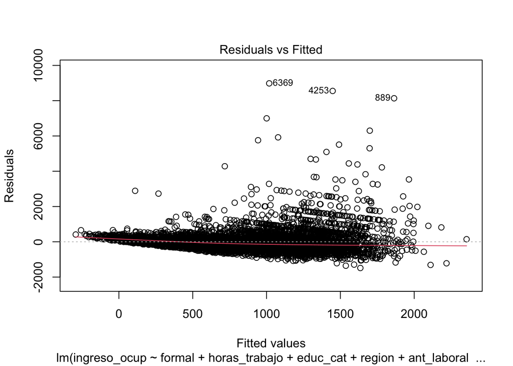

Los residuos no se distribuyen de manera uniforme. Aplicamos el test de Breusch-Pagan ($H_0$: variancia constante):

```r
bptest(M2)
```

```
    studentized Breusch-Pagan test

data:  M2
BP = 147.81, df = 22, p-value < 2.2e-16
```

Se rechaza $H_0$, indicando heterocedasticidad. Dado el tamaño muestral, la heterocedasticidad no invalida la estimación puntual de los coeficientes, pero sí puede afectar los errores estándar clásicos. Sería conveniente complementar el análisis con errores estándar robustos (HC).

**Normalidad**

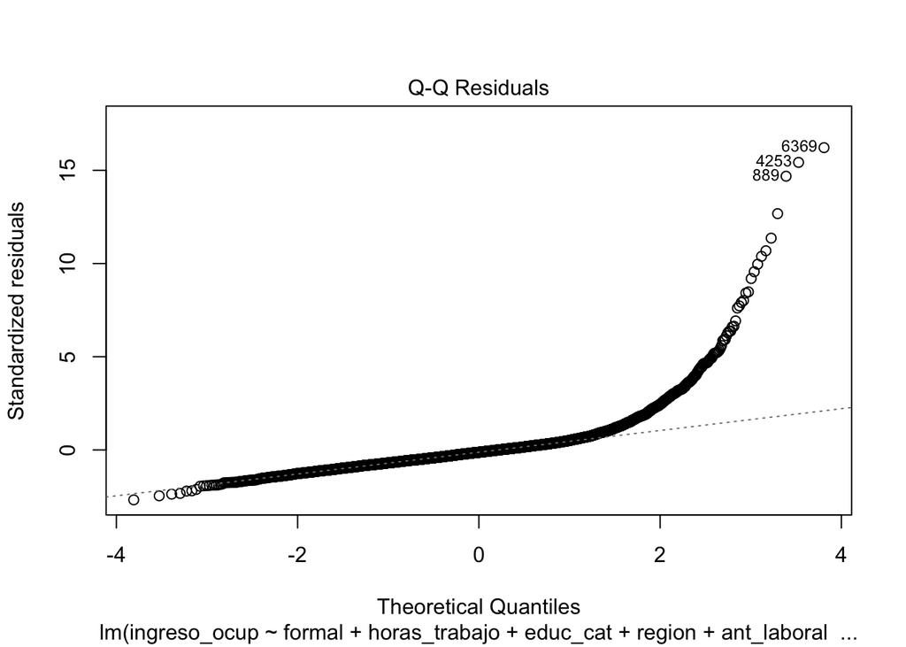

Aplicamos el test de Anderson-Darling ($H_0$: residuos normales):

```r
ad.test(residuals(M2))
```

```
    Anderson-Darling normality test

data:  residuals(M2)
A = 329.65, p-value < 2.2e-16
```

Se rechaza $H_0$. Dado el gran tamaño muestral, la no normalidad no resulta especialmente preocupante para la estimación puntual de los coeficientes, por aplicación del Teorema Central del Límite.

**Independencia**

```r
dwtest(M2)
```

```
    Durbin-Watson test

data:  M2
DW = 2.0058, p-value = 0.5972
alternative hypothesis: true autocorrelation is greater than 0
```

Dado que los datos provienen de una encuesta (EPH) y no de una serie temporal, este test debe interpretarse con cautela.

**Colinealidad (VIF)**

```r
vif(M2)
```

```
                  GVIF Df GVIF^(1/(2*Df))
formal        1.514232  1        1.230541
horas_trabajo 1.178292  1        1.085491
educ_cat      1.306681  3        1.045590
region        1.069094  5        1.006704
ant_laboral   2.046311  6        1.061486
sexo          1.313161  1        1.145933
est_civil     1.446218  4        1.047199
edad          1.621714  1        1.273465
```

Para variables categóricas se reporta el GVIF ajustado. Valores de $GVIF^{1/(2 \cdot Df)} > \sqrt{5} \approx 2.24$ indican problemas. No se detecta colinealidad.

**Casos atípicos e influyentes**

Se consideran outliers las observaciones con residuos estandarizados o estudentizados $> |3|$:

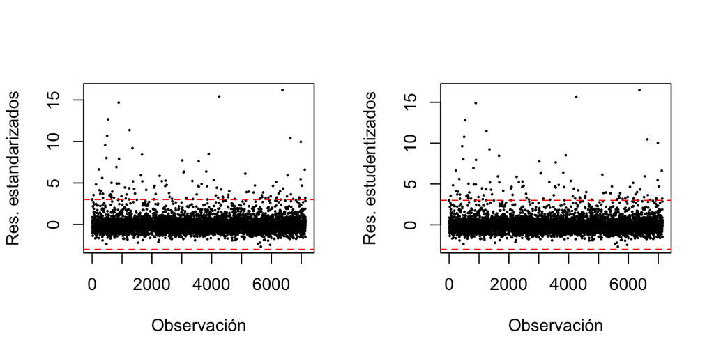

```r
cat("Outliers estandarizados (>|3|):", sum(abs(rstandard(M2)) > 3), "\n")
```

```
Outliers estandarizados (>|3|): 115
```

```r
cat("Outliers estudentizados (>|3|):", sum(abs(rstudent(M2)) > 3))
```

```
Outliers estudentizados (>|3|): 115
```

Distancia de Cook (umbral = 1):

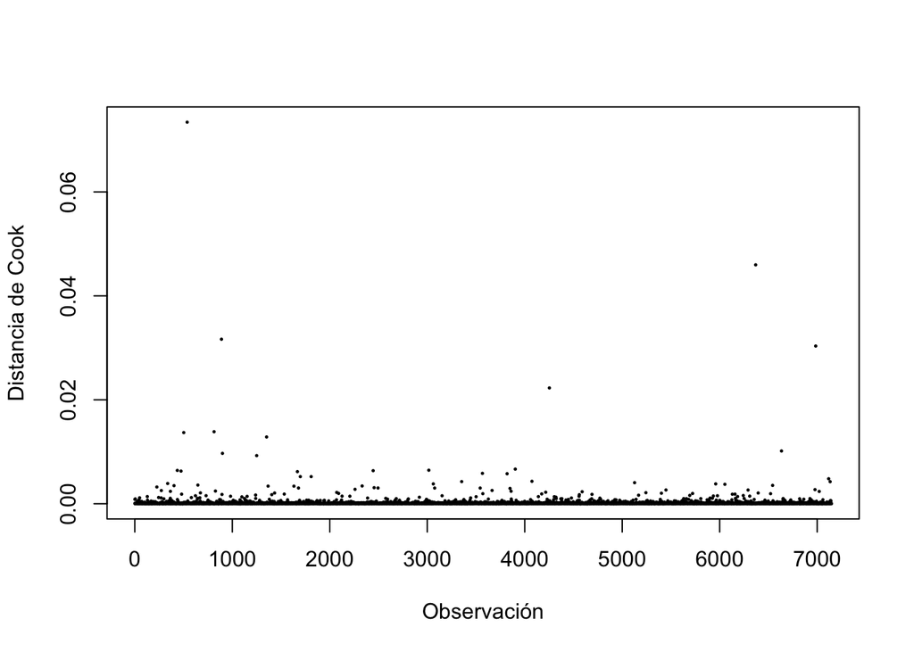

```r
cat("Obs. con Cook > 1:", sum(cooks.distance(M2) > 1))
```

```
Obs. con Cook > 1: 0
```

DFBETAS y DFFITS:

```r
n_t <- nrow(train); p_t <- length(coef(M2))
cat("DFBETAS > 2/sqrt(n):",
    sum(apply(abs(dfbetas(M2)), 1, max) > 2/sqrt(n_t)), "\n")
```

```
DFBETAS > 2/sqrt(n): 1493
```

```r
cat("DFFITS > 2*sqrt(p/n):",
    sum(abs(dffits(M2)) > 2*sqrt(p_t/n_t)))
```

```
DFFITS > 2*sqrt(p/n): 216
```

No se eliminan estas observaciones ya que representan la heterogeneidad real del mercado laboral argentino y no errores de medición. Aunque los umbrales de DFBETAS y DFFITS marcan muchos casos (algo esperable con muestras grandes), **ninguna observación presenta distancia de Cook mayor a 1**, por lo que no se observan casos individualmente dominantes sobre el ajuste.

> *5. Considerando el modelo elegido, interpretar en palabras del problema los efectos estimados de los predictores sobre la respuesta, incluida su significación estadística (resultados del test t).*

```r
s_m2 <- summary(M2)
s_m2
```

```
Call:
lm(formula = ingreso_ocup ~ formal + horas_trabajo + educ_cat +
    region + ant_laboral + sexo + est_civil + edad, data = train)

Residuals:
    Min      1Q  Median      3Q     Max
-1485.4  -286.9   -69.5   149.4  8982.0

Coefficients:
                                Estimate Std. Error t value Pr(>|t|)
(Intercept)                     117.8082    66.8915   1.761 0.078250 .
formalSi                        293.3404    16.8285  17.431  < 2e-16 ***
horas_trabajo                     9.4570     0.4493  21.049  < 2e-16 ***
educ_catPrimario                 75.9253    47.4484   1.600 0.109606
educ_catSecundario              197.2788    47.0740   4.191 2.81e-05 ***
educ_catSuperior                554.6200    48.5421  11.426  < 2e-16 ***
regionGran Buenos Aires         150.8658    28.0525   5.378 7.77e-08 ***
regionNoreste                   -87.5700    31.9630  -2.740 0.006164 **
regionNoroeste                 -113.5028    24.7453  -4.587 4.58e-06 ***
regionPampeana                   87.1381    24.4345   3.566 0.000365 ***
regionPatagonia                 382.0029    28.3875  13.457  < 2e-16 ***
ant_laboral1 a 5 años           -81.8032    17.2817  -4.734 2.25e-06 ***
ant_laboral6 meses a 1 año     -149.1938    34.9713  -4.266 2.01e-05 ***
ant_laboralEntre 3 y 6 meses   -115.1560    39.9429  -2.883 0.003951 **
ant_laboral1 a 3 meses          -64.4796    37.9569  -1.699 0.089409 .
ant_laboralMenos de 1 mes      -255.4889    72.4000  -3.529 0.000420 ***
ant_laboralDesconocido         -203.7208    27.1399  -7.506 6.82e-14 ***
sexoMujer                      -151.2938    15.0905 -10.026  < 2e-16 ***
est_civilseparado o divorciado -118.0589    26.7519  -4.413 1.03e-05 ***
est_civilsoltero               -124.7733    19.8756  -6.278 3.64e-10 ***
est_civilunido                  -52.7853    19.2243  -2.746 0.006052 **
est_civilviudo                 -116.7687    54.7448  -2.133 0.032962 *
edad                              3.8527     0.6842   5.631 1.86e-08 ***
---
Signif. codes:  0 '***' 0.001 '**' 0.01 '*' 0.05 '.' 0.1 ' ' 1

Residual standard error: 555 on 7122 degrees of freedom
Multiple R-squared:  0.3738,    Adjusted R-squared:  0.3718
F-statistic: 193.2 on 22 and 7122 DF,  p-value: < 2.2e-16
```

# 2 Consigna II: Regularización y Predicción

> *1. Ajustar el modelo elegido mediante la técnica Ridge, eligiendo el parámetro de penalidad mediante validación cruzada k-fold. Informar el valor óptimo de λ y comparar el resultado con MCO.*

```r
X_train <- model.matrix(M2, data = train)[, -1]
y_train <- train$ingreso_ocup
X_test  <- model.matrix(M2, data = test)[, -1]
y_test  <- test$ingreso_ocup

set.seed(2026)
cv_ridge <- cv.glmnet(x = X_train, y = y_train, alpha = 0, nfolds = 10)
```

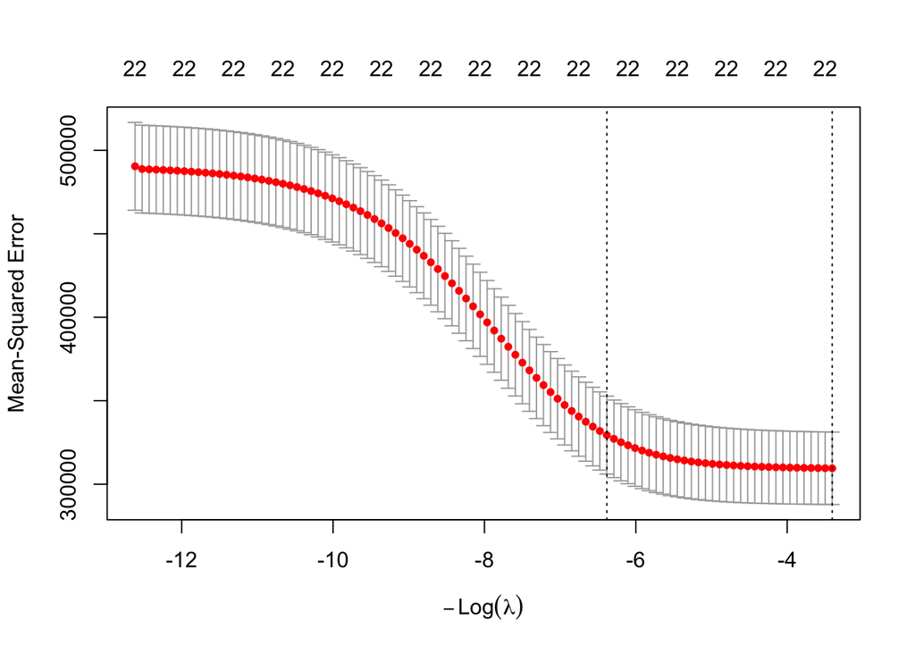

```r
cat("Lambda mínimo:", cv_ridge$lambda.min, "\n")
```

```
Lambda mínimo: 30.12793
```

```r
cat("Lambda 1se:   ", cv_ridge$lambda.1se)
```

```
Lambda 1se:    591.4236
```

Se elige **lambda.min** porque minimiza el error de validación cruzada. **lambda.1se** sería una alternativa más parsimoniosa, con mayor penalización, pero en este caso optamos por el que ofrece mejor ajuste. Comparamos coeficientes:

```r
m_ridge <- glmnet(x = X_train, y = y_train,
                  alpha = 0, lambda = cv_ridge$lambda.min)
data.frame(MCO = round(coef(M2), 4),
           Ridge = round(as.vector(coef(m_ridge)), 4))
```

```
                                     MCO     Ridge
(Intercept)                     117.8082  293.0017
formalSi                        293.3404  293.2672
horas_trabajo                     9.4570    9.1004
educ_catPrimario                 75.9253  -71.6830
educ_catSecundario              197.2788   44.9616
educ_catSuperior                554.6200  388.8480
regionGran Buenos Aires         150.8658  131.0781
regionNoreste                   -87.5700  -97.6264
regionNoroeste                 -113.5028 -126.8265
regionPampeana                   87.1381   67.8639
regionPatagonia                 382.0029  353.7324
ant_laboral1 a 5 años           -81.8032  -80.4494
ant_laboral6 meses a 1 año     -149.1938 -146.4742
ant_laboralEntre 3 y 6 meses   -115.1560 -113.7548
ant_laboral1 a 3 meses          -64.4796  -67.5804
ant_laboralMenos de 1 mes      -255.4889 -257.9636
ant_laboralDesconocido         -203.7208 -213.1316
sexoMujer                      -151.2938 -143.0357
est_civilseparado o divorciado -118.0589 -107.2167
est_civilsoltero               -124.7733 -115.9327
est_civilunido                  -52.7853  -45.2087
est_civilviudo                 -116.7687 -117.6787
edad                              3.8527    3.7402
```

> *2. Ajustar el modelo elegido mediante la técnica Lasso, eligiendo el parámetro de penalidad mediante validación cruzada k-fold. Informar el valor óptimo de λ y comparar el resultado con MCO.*

```r
set.seed(2026)
cv_lasso <- cv.glmnet(x = X_train, y = y_train, alpha = 1, nfolds = 10)
```

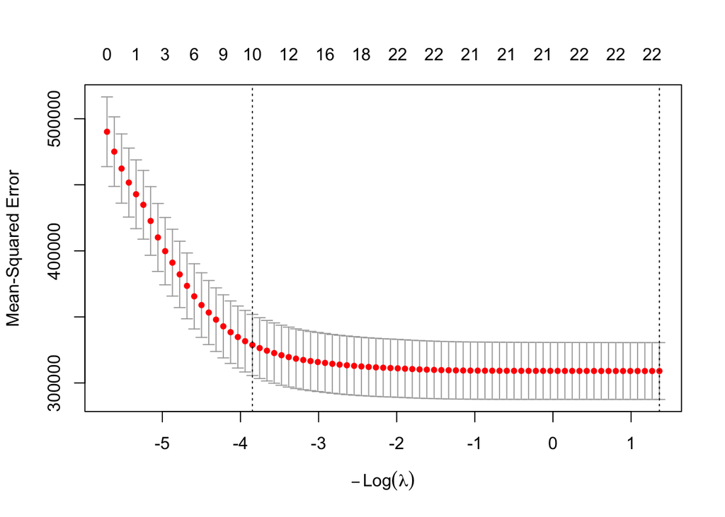

```r
cat("Lambda mínimo:", cv_lasso$lambda.min, "\n")
```

```
Lambda mínimo: 0.2560131
```

```r
cat("Lambda 1se:   ", cv_lasso$lambda.1se)
```

```
Lambda 1se:    46.86931
```

```r
m_lasso <- glmnet(x = X_train, y = y_train,
                  alpha = 1, lambda = cv_lasso$lambda.min)
data.frame(MCO = round(coef(M2), 4),
           Lasso = round(as.vector(coef(m_lasso)), 4))
```

```
                                     MCO     Lasso
(Intercept)                     117.8082  139.5053
formalSi                        293.3404  294.5096
horas_trabajo                     9.4570    9.4465
educ_catPrimario                 75.9253   52.8160
educ_catSecundario              197.2788  174.2966
educ_catSuperior                554.6200  531.5942
regionGran Buenos Aires         150.8658  149.0517
regionNoreste                   -87.5700  -87.6623
regionNoroeste                 -113.5028 -114.2479
regionPampeana                   87.1381   85.3410
regionPatagonia                 382.0029  380.1927
ant_laboral1 a 5 años           -81.8032  -80.8984
ant_laboral6 meses a 1 año     -149.1938 -147.3181
ant_laboralEntre 3 y 6 meses   -115.1560 -112.9175
ant_laboral1 a 3 meses          -64.4796  -62.4995
ant_laboralMenos de 1 mes      -255.4889 -252.9273
ant_laboralDesconocido         -203.7208 -203.0870
sexoMujer                      -151.2938 -150.7364
est_civilseparado o divorciado -118.0589 -115.8818
est_civilsoltero               -124.7733 -123.1693
est_civilunido                  -52.7853  -51.1823
est_civilviudo                 -116.7687 -114.5632
edad                              3.8527    3.8414
```

Lasso puede llevar coeficientes exactamente a cero, realizando estimación y selección de variables simultáneamente. En este caso, usando $\lambda_{min}$, Lasso no elimina prácticamente variables, lo cual indica que todas conservan cierto aporte predictivo bajo este nivel de penalización.

> *3. Evaluar la capacidad predictiva de los modelos MCO, Ridge y Lasso por intermedio de alguna medida del error de predicción, y determinar cuál de los tres modelos es el más adecuado. Utilizar el bloque de datos de prueba.*

```r
pred_mco   <- predict(M2, newdata = test)
pred_ridge <- as.vector(predict(m_ridge, newx = X_test, s = cv_ridge$lambda.min))
pred_lasso <- as.vector(predict(m_lasso, newx = X_test, s = cv_lasso$lambda.min))
sct <- sum((y_test - mean(y_test))^2)

data.frame(
  Modelo = c("MCO", "Ridge", "Lasso"),
  CME_Test = round(c(mean((y_test-pred_mco)^2), mean((y_test-pred_ridge)^2),
                      mean((y_test-pred_lasso)^2)), 2),
  R2_Test = round(c(1-sum((y_test-pred_mco)^2)/sct, 1-sum((y_test-pred_ridge)^2)/sct,
                     1-sum((y_test-pred_lasso)^2)/sct), 4)
)
```

```
  Modelo CME_Test R2_Test
1    MCO 301227.1  0.3767
2  Ridge 301360.1  0.3765
3  Lasso 301185.5  0.3768
```

Los tres modelos presentan resultados muy similares. Lasso obtiene el menor CME, aunque la diferencia es mínima. En términos prácticos, los tres modelos tienen desempeño equivalente. Esto es esperable en escenarios donde el tamaño muestral es mucho mayor a la cantidad de predictores y no existe multicolinealidad severa: el sesgo introducido por la penalización no mejora la varianza del estimador MCO, validando la robustez del modelo original. Esto coincide con lo esperado para datos de la EPH, donde contamos con más de 10.000 observaciones y un número moderado de variables.

# 3 Consigna III: Regresión Logística

> *1. Sobre el conjunto de datos original, definir la variable respuesta: Y=0 si ingreso < 1000, Y=1 si ingreso ≥ 1000.*

```r
datos_logit <- datos_modelo %>%
  mutate(Y = ifelse(ingreso_ocup >= 1000, 1, 0))
table(datos_logit$Y)
```

```
   0    1
6668 3540
```

> *2. Dividir aleatoriamente al conjunto de datos en bloques de entrenamiento (70%) y prueba (30%), utilizando createDataPartition() para asegurar proporciones balanceadas.*

```r
set.seed(2026)
idx_logit <- createDataPartition(datos_logit$Y, p = 0.70, list = FALSE)
train_logit <- datos_logit[idx_logit, ]
test_logit  <- datos_logit[-idx_logit, ]
cat("Prop Y=1 Train:", mean(train_logit$Y), "\n")
```

```
Prop Y=1 Train: 0.3508256
```

```r
cat("Prop Y=1 Test: ", mean(test_logit$Y))
```

```
Prop Y=1 Test:  0.3373612
```

Se verifica que `createDataPartition()` mantiene la proporción de éxitos balanceada.

> *3. Ajustar un modelo de regresión logística con las mismas variables del modelo elegido en la Consigna I. Interpretar las razones de odds de los predictores significativos al 5%.*

```r
vars_m2 <- attr(terms(M2), "term.labels")
formula_logit <- as.formula(paste("Y ~", paste(vars_m2, collapse = " + ")))
MLog <- glm(formula_logit, data = train_logit,
            family = binomial(link = "logit"))
summary(MLog)
```

```
Call:
glm(formula = formula_logit, family = binomial(link = "logit"),
    data = train_logit)

Coefficients:
                                Estimate Std. Error z value Pr(>|z|)
(Intercept)                    -5.154068   0.402919 -12.792  < 2e-16 ***
formalSi                        1.594281   0.091395  17.444  < 2e-16 ***
horas_trabajo                   0.043666   0.002439  17.900  < 2e-16 ***
educ_catPrimario                0.589295   0.318074   1.853 0.063926 .
educ_catSecundario              1.424538   0.314341   4.532 5.85e-06 ***
educ_catSuperior                2.476578   0.318593   7.773 7.64e-15 ***
regionGran Buenos Aires         0.565982   0.131203   4.314 1.60e-05 ***
regionNoreste                  -0.561160   0.155513  -3.608 0.000308 ***
regionNoroeste                 -0.806767   0.124436  -6.483 8.97e-11 ***
regionPampeana                  0.372019   0.117382   3.169 0.001528 **
regionPatagonia                 1.707307   0.137596  12.408  < 2e-16 ***
ant_laboral1 a 5 años          -0.344602   0.078839  -4.371 1.24e-05 ***
ant_laboral6 meses a 1 año     -0.549532   0.184243  -2.983 0.002858 **
ant_laboralEntre 3 y 6 meses   -0.915998   0.230595  -3.972 7.12e-05 ***
ant_laboral1 a 3 meses         -0.633790   0.228149  -2.778 0.005470 **
ant_laboralMenos de 1 mes      -1.218056   0.497815  -2.447 0.014413 *
ant_laboralDesconocido         -2.046042   0.270973  -7.551 4.33e-14 ***
sexoMujer                      -0.732046   0.071665 -10.215  < 2e-16 ***
est_civilseparado o divorciado -0.534798   0.127711  -4.188 2.82e-05 ***
est_civilsoltero               -0.534363   0.092014  -5.807 6.34e-09 ***
est_civilunido                 -0.157130   0.087198  -1.802 0.071547 .
est_civilviudo                 -0.507655   0.293011  -1.733 0.083177 .
edad                            0.019604   0.003381   5.798 6.71e-09 ***
---
Signif. codes:  0 '***' 0.001 '**' 0.01 '*' 0.05 '.' 0.1 ' ' 1

(Dispersion parameter for binomial family taken to be 1)

    Null deviance: 9260.6  on 7145  degrees of freedom
Residual deviance: 6102.0  on 7123  degrees of freedom
AIC: 6148

Number of Fisher Scoring iterations: 6
```

Razones de odds para predictores significativos al 5% (test de Wald):

```r
coefs <- summary(MLog)$coefficients
sig <- coefs[coefs[, 4] < 0.05, , drop = FALSE]

data.frame(
  OR = round(exp(sig[,1]), 4),
  IC_25 = round(exp(sig[,1] - 1.96*sig[,2]), 4),
  IC_97 = round(exp(sig[,1] + 1.96*sig[,2]), 4),
  Variacion = paste0(round((exp(sig[,1])-1)*100, 1), "%"),
  p_valor = ifelse(sig[,4] < 2e-16, "< 2e-16",
                   formatC(sig[,4], format="g", digits=3))
)
```

```
                                    OR  IC_25   IC_97 Variacion  p_valor
(Intercept)                     0.0058 0.0026  0.0127    -99.4%  < 2e-16
formalSi                        4.9248 4.1171  5.8909    392.5%  < 2e-16
horas_trabajo                   1.0446 1.0397  1.0496      4.5%  < 2e-16
educ_catSecundario              4.1559 2.2444  7.6956    315.6% 5.85e-06
educ_catSuperior               11.9005 6.3734 22.2206     1090% 7.64e-15
regionGran Buenos Aires         1.7612 1.3618  2.2776     76.1%  1.6e-05
regionNoreste                   0.5705 0.4206  0.7739    -42.9% 0.000308
regionNoroeste                  0.4463 0.3497  0.5696    -55.4% 8.97e-11
regionPampeana                  1.4507 1.1525  1.8259     45.1%  0.00153
regionPatagonia                 5.5141 4.2107  7.2210    451.4%  < 2e-16
ant_laboral1 a 5 años           0.7085 0.6071  0.8269    -29.1% 1.24e-05
ant_laboral6 meses a 1 año      0.5772 0.4023  0.8283    -42.3%  0.00286
ant_laboralEntre 3 y 6 meses    0.4001 0.2546  0.6287      -60% 7.12e-05
ant_laboral1 a 3 meses          0.5306 0.3393  0.8298    -46.9%  0.00547
ant_laboralMenos de 1 mes       0.2958 0.1115  0.7848    -70.4%   0.0144
ant_laboralDesconocido          0.1292 0.0760  0.2198    -87.1% 4.33e-14
sexoMujer                       0.4809 0.4179  0.5535    -51.9%  < 2e-16
est_civilseparado o divorciado  0.5858 0.4561  0.7524    -41.4% 2.82e-05
est_civilsoltero                0.5860 0.4893  0.7019    -41.4% 6.34e-09
edad                            1.0198 1.0131  1.0266        2% 6.71e-09
```

Un OR > 1 indica mayor chance de percibir un ingreso $\geq$ 1000 mil pesos respecto a la categoría de referencia; OR < 1 la disminuye. Por ejemplo:

- Estar registrado formalmente (OR = 4.92) implica que los trabajadores formales tienen odds de ganar al menos 1000 mil pesos aproximadamente 4.92 veces mayores que los informales.
- La Patagonia (OR = 5.51) presenta las mayores chances respecto a Cuyo.
- La educación Superior (OR = 11.9) muestra el mayor efecto positivo sobre las chances.

> *4. Elegir el punto de corte óptimo para clasificación mediante el método de la curva ROC.*

```r
curvaROC <- roc(train_logit$Y, fitted.values(MLog), quiet = TRUE)
```

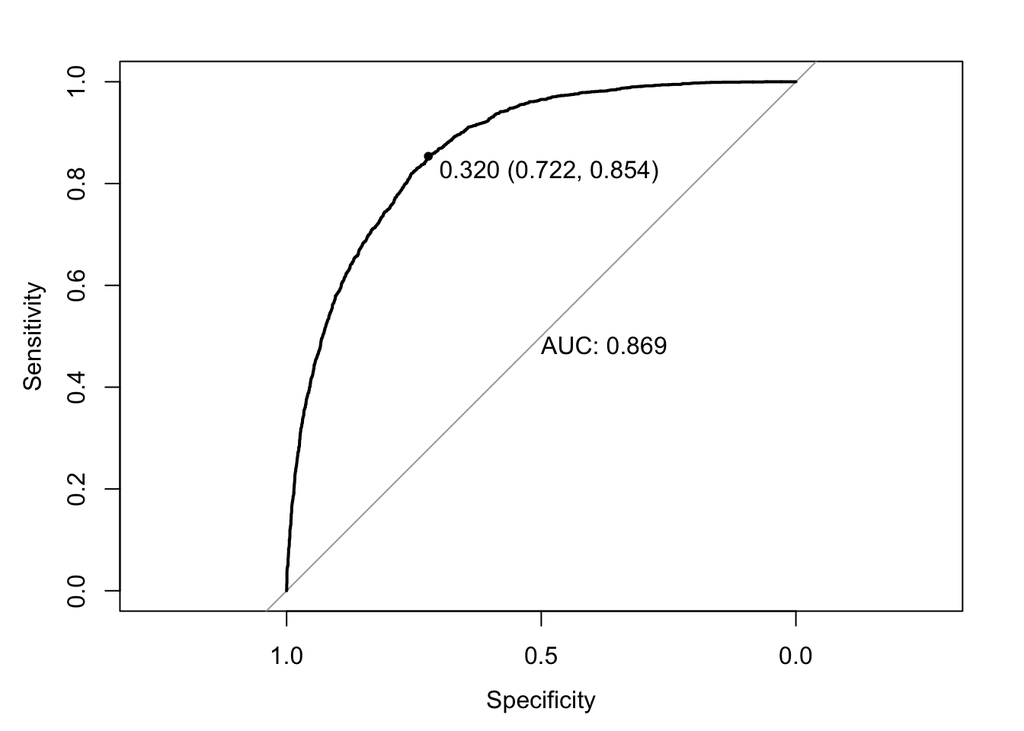

```r
corte <- coords(curvaROC, "best", ret = "threshold")$threshold
cat("Punto de corte óptimo:", corte, "\n")
```

```
Punto de corte óptimo: 0.319939
```

```r
cat("AUC:", as.numeric(auc(curvaROC)))
```

```
AUC: 0.8685075
```

El punto de corte se halló mediante la curva ROC para maximizar sensibilidad y especificidad conjuntamente. No se utilizó el umbral de 0.5 por defecto.

Para evaluar la generalización del modelo, calculamos también el AUC sobre el conjunto de prueba:

```r
roc_test <- roc(test_logit$Y,
                predict(MLog, newdata = test_logit, type = "response"),
                quiet = TRUE)
cat("AUC en test:", as.numeric(auc(roc_test)))
```

```
AUC en test: 0.8662344
```

> *5. Utilizando el punto de corte hallado, clasificar los individuos del conjunto de datos de prueba y construir la matriz de confusión. Informar e interpretar precisión, sensibilidad, especificidad, VPP y VPN.*

```r
prob_test  <- predict(MLog, newdata = test_logit, type = "response")
pred_clase <- factor(ifelse(prob_test >= corte, 1, 0), levels = c("0","1"))
real_clase <- factor(test_logit$Y, levels = c("0","1"))
mc <- confusionMatrix(pred_clase, real_clase, positive = "1")
mc
```

```
Confusion Matrix and Statistics

          Reference
Prediction    0    1
         0 1453  155
         1  576  878

               Accuracy : 0.7613
                 95% CI : (0.7458, 0.7763)
    No Information Rate : 0.6626
    P-Value [Acc > NIR] : < 2.2e-16

                  Kappa : 0.5146

 Mcnemar's Test P-Value : < 2.2e-16

            Sensitivity : 0.8500
            Specificity : 0.7161
         Pos Pred Value : 0.6039
         Neg Pred Value : 0.9036
             Prevalence : 0.3374
         Detection Rate : 0.2867
   Detection Prevalence : 0.4749
      Balanced Accuracy : 0.7830

       'Positive' Class : 1
```

- **Precisión**: proporción total de individuos correctamente clasificados.
- **Sensibilidad**: proporción de $Y=1$ correctamente identificados.
- **Especificidad**: proporción de $Y=0$ correctamente identificados.
- **VPP**: cuando predice $Y=1$, proporción de aciertos.
- **VPN**: cuando predice $Y=0$, proporción de aciertos.

El modelo detecta bien a quienes tienen ingreso alto (sensibilidad elevada). Además, cuando predice ingreso bajo, acierta en un porcentaje alto de los casos (VPN alto). El VPP es algo menor, lo que indica que entre los clasificados como ingreso alto hay una proporción relevante de falsos positivos.